# US Health Insurance EDA

**Explore the distribution of categorical variables:`Sex`,`Smoker`,`Region` and `Children`**

```python
# Create a function that returns a Pie chart for categorical variable:
def pie_chart(x = 'smoker'):
    """
    Function creates a Pie chart for categorical variables.
    """
    fig, ax = plt.subplots(figsize=(8, 6), subplot_kw=dict(aspect="equal"))

    s = df.groupby(x).size()

    mydata_values = s.values.tolist()
    mydata_index = s.index.tolist()

    def func(pct, allvals):
        absolute = int(pct/100.*np.sum(allvals))
        return "{:.1f}%\n({:d})".format(pct, absolute)


    wedges, texts, autotexts = ax.pie(mydata_values, autopct=lambda pct: func(pct, mydata_values),
                                      textprops=dict(color="w"))

    ax.legend(wedges, mydata_index,
              title="Index",
              loc="center left",
              bbox_to_anchor=(1, 0, 0.5, 1))

    plt.setp(autotexts, size=12, weight="bold")

    ax.set_title(f'{x.capitalize()} Piechart')

    plt.show()
```

**Sex Distribution**

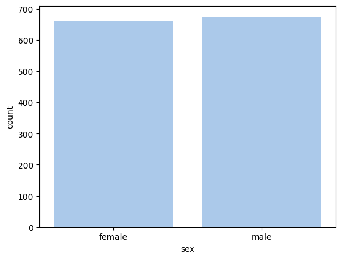

```python
sns.countplot(x = 'sex', data = df)
```

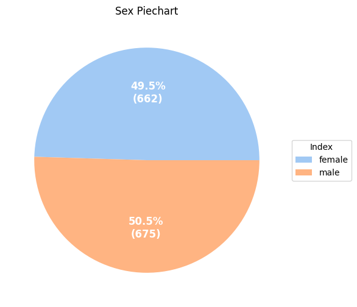

```python
pie_chart('sex')
```

**We can notice that:**

- The dataset is almost evenly distributed among genders, with 675 Males (50.5%) and 662 Females (49.5%).

**Smokers Distribution**

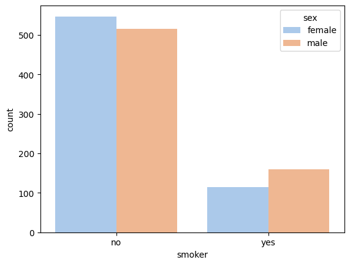

```python
sns.countplot(x = 'smoker', hue = 'sex', data = df)
```

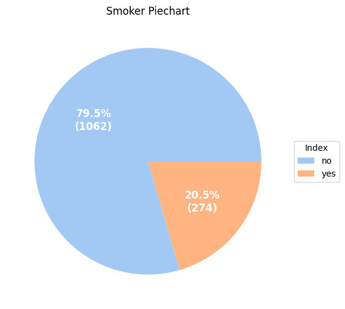

```python
pie_chart('smoker')
```

Are average premium charges for smokers significantly higher than non-smokers?

```python
df['charges'].groupby(df['smoker']).mean()
```

```
smoker
no      8440.660307
yes    32050.231832
Name: charges, dtype: float64
```

```python
df.groupby(['smoker', 'sex']).agg('count')
```

| smoker | sex | age | bmi | children | region | charges |
| --- | --- | --- | --- | --- | --- | --- |
| no | female | 547 | 547 | 547 | 547 | 547 |
|  | male | 516 | 516 | 516 | 516 | 516 |
| yes | female | 115 | 115 | 115 | 115 | 115 |
|  | male | 159 | 159 | 159 | 159 | 159 |

- yes, average premium charges for smokers are indeed significantly higher than non-smokers.

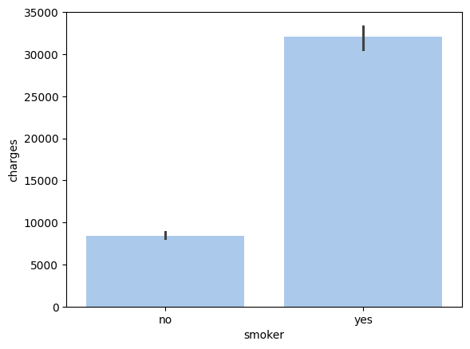

```python
sns.barplot(x = "smoker", y = "charges", data = df)
```

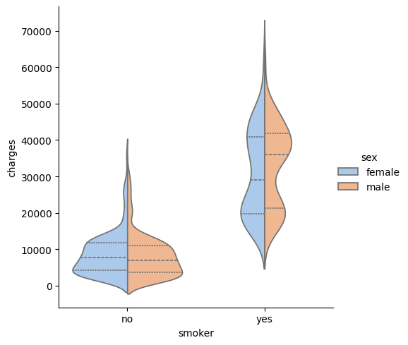

```python
sns.catplot(x="smoker", y="charges", hue="sex",
            kind="violin", inner="quartiles", split=True,
            palette="pastel", data=df)
```

**We can notice that:**

- Of the total 1337 insured, 274 (20.5%) are smokers and the rest are non-smokers.
- Among 274 smokers, proportion of males (159) are higher than females (115).
- The average insurance premium for smokers are significantly higher than non-smokers.

**Regions Distribution**

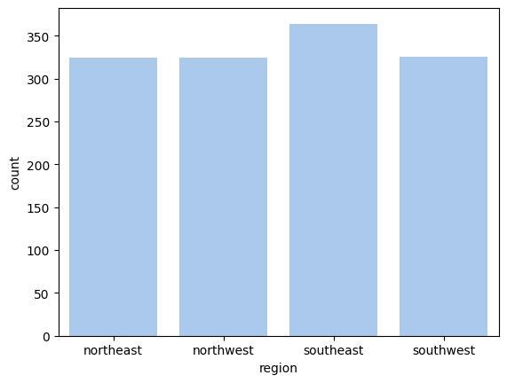

```python
sns.countplot(x = 'region', data = df)
```

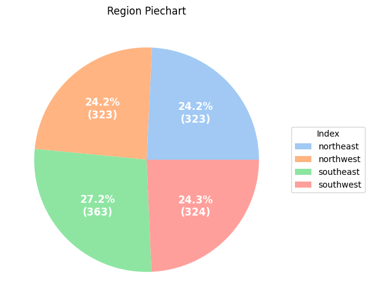

```python
pie_chart('region')
```

**We can notice that:**

- All four regions are represented approximately evenly in the dataset.

**Number of children**

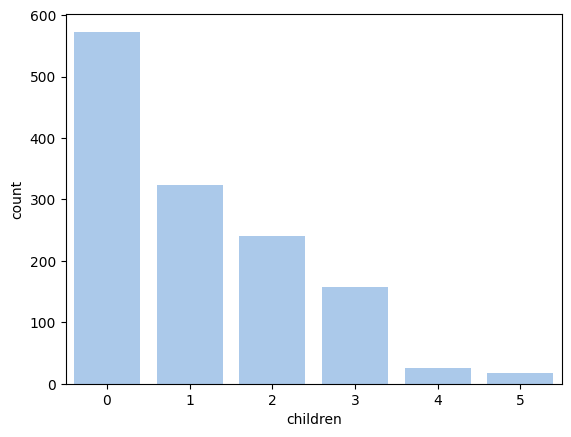

```python
sns.countplot(x = 'children', data = df)
```

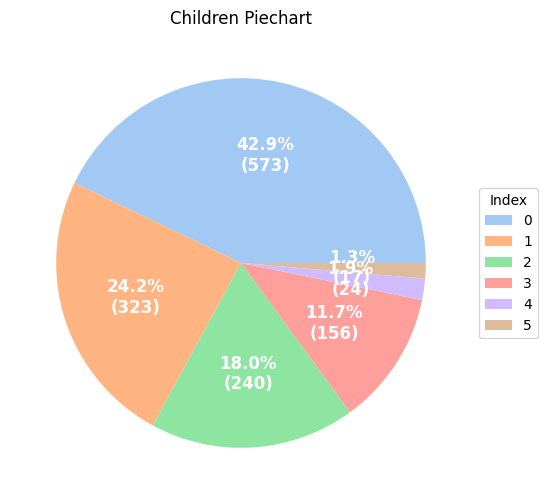

```python
pie_chart('children')
```

```python
df.groupby(['children']).agg('count')['age']
```

```
children
0    573
1    324
2    240
3    157
4     25
5     18
Name: age, dtype: int64
```

**We can notice that:**

- In the dataset, approximately 85% (1137/1337) of the insured have less than 3 children.

```python
# Next, we select all columns of the dataFrame with datatype = category:
cat_columns = df.select_dtypes(['category']).columns
cat_columns
```

```
Index(['sex', 'children', 'smoker', 'region'], dtype='object')
```

```python
# Finally, we transform the original columns by replacing the elements with their category codes:
df[cat_columns] = df[cat_columns].apply(lambda x: x.cat.codes)
df.head()
```

|  | age | sex | bmi | children | smoker | region | charges |
| --- | --- | --- | --- | --- | --- | --- | --- |
| 0 | 19 | 0 | 27.900 | 0 | 1 | 3 | 16884.92400 |
| 1 | 18 | 1 | 33.770 | 1 | 0 | 2 | 1725.55230 |
| 2 | 28 | 1 | 33.000 | 3 | 0 | 2 | 4449.46200 |
| 3 | 33 | 1 | 22.705 | 0 | 0 | 1 | 21984.47061 |
| 4 | 32 | 1 | 28.880 | 0 | 0 | 1 | 3866.85520 |

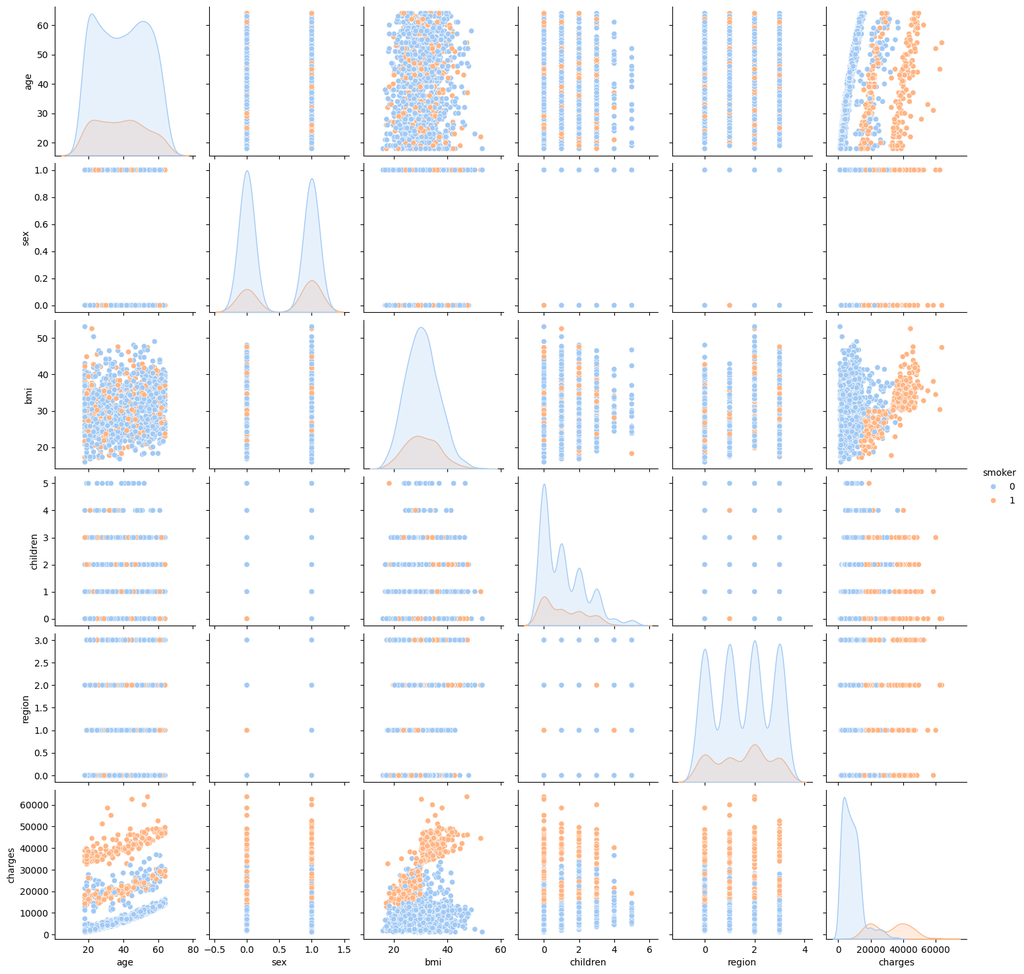

```python
# Now we can plot all columns of our dataset in a pairplot!
sns.pairplot(df, hue  = 'smoker')
```

A particularly interesting relationship between insurance premium charges, BMI and smoking status(Smoker/Non-smoker) can be seen in this graph:

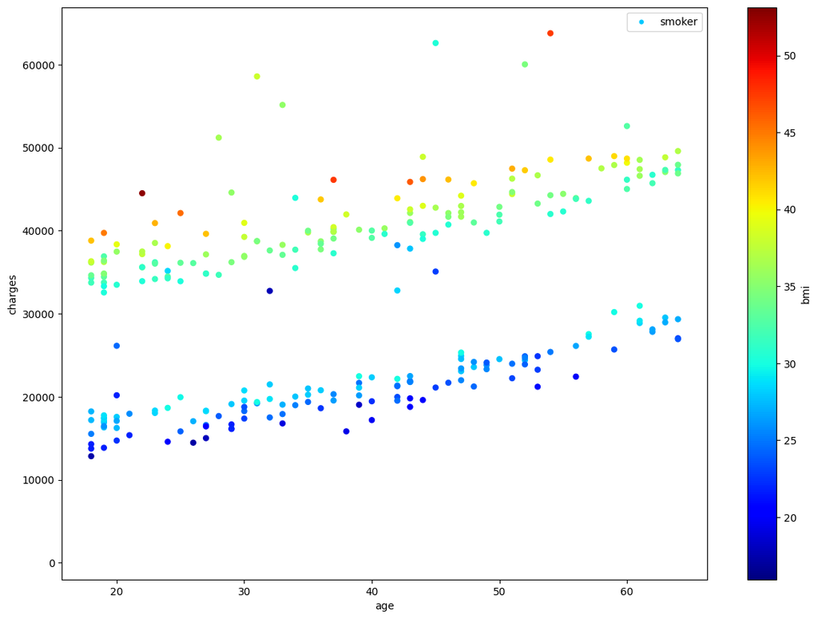

```python
df.plot(kind="scatter", x="age", y="charges",
    s=df["smoker"]*25, label="smoker", figsize=(14,10),
    c='bmi', cmap=plt.get_cmap("jet"), colorbar=True,
    sharex=False)
plt.legend()
```

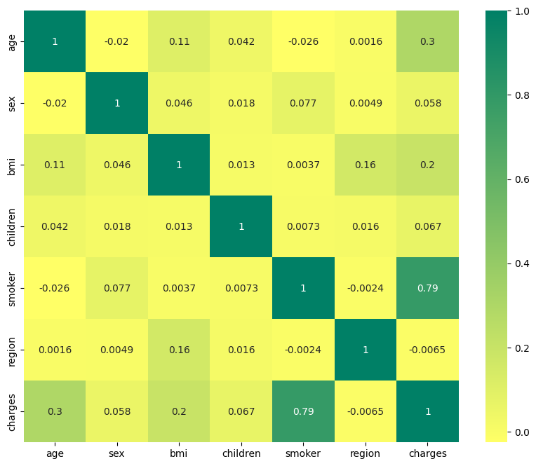

```python
corr = df.corr()
plt.figure(figsize=(10, 8))
sns.heatmap(corr, annot=True, cmap = 'summer_r')
```

- From the correlation heatmap, we can conclude that the premium charges show a weak positive correlation with Age and BMI of the insured, and a strong positive correlation with smoking habit.